# Decision Trees

INSOFE Lab Activity on Decision Trees

30th September 2018

# Decision Trees - Supervised models

**NOTE**: Before starting this assignment please remember to clear your environment, you can do that by running the following code chunk

```r
rm(list = ls(all=TRUE))
```

# C5.0 Trees

## Goal

- The goal of this activity is to predict whether a car is recommended for purchase, given various qualities of the car
- For this we analyze data where expert car analysts make recommendations regarding car purchase
- By analyzing their expert decision support system, we can gain interesting insights in the business oppurtunities available in the car market

## Agenda

- Get the data
- Data Pre-processing
- Build a model
- Predictions
- Communication

## Reading & Understanding the Data

### Read the Data

- Make sure the dataset is located in your current working directory, or else you can change your working directory using the “setwd()” function.

```r
car_data <- read.csv("car_eval.csv")
```

### Understand the data

- Use the str(), summary(), head() and tail() functions to get the dimensions and types of attributes in the dataset
- The dataset has 1728 observations and 7 variables

```r
str(car_data)
```

```
## 'data.frame':    1728 obs. of  7 variables:
##  $ buying_price: Factor w/ 4 levels "high","low","med",..: 4 4 4 4 4 4 4 4 4 4 ...
##  $ maint_cost  : Factor w/ 4 levels "high","low","med",..: 4 4 4 4 4 4 4 4 4 4 ...
##  $ doors       : Factor w/ 4 levels "2","3","4","5more": 1 1 1 1 1 1 1 1 1 1 ...
##  $ persons     : Factor w/ 3 levels "2","4","more": 1 1 1 1 1 1 1 1 1 2 ...
##  $ lug_boot    : Factor w/ 3 levels "big","med","small": 3 3 3 2 2 2 1 1 1 3 ...
##  $ safety      : Factor w/ 3 levels "high","low","med": 2 3 1 2 3 1 2 3 1 2 ...
##  $ decision    : Factor w/ 2 levels "notRecommended",..: 1 1 1 1 1 1 1 1 1 1 ...
```

```r
summary(car_data)
```

```
##  buying_price maint_cost    doors     persons     lug_boot    safety
##  high :432    high :432   2    :432   2   :576   big  :576   high:576
##  low  :432    low  :432   3    :432   4   :576   med  :576   low :576
##  med  :432    med  :432   4    :432   more:576   small:576   med :576
##  vhigh:432    vhigh:432   5more:432
##            decision
##  notRecommended:1210
##  recommended   : 518
##
##
```

```r
head(car_data)
```

```
##   buying_price maint_cost doors persons lug_boot safety       decision
## 1        vhigh      vhigh     2       2    small    low notRecommended
## 2        vhigh      vhigh     2       2    small    med notRecommended
## 3        vhigh      vhigh     2       2    small   high notRecommended
## 4        vhigh      vhigh     2       2      med    low notRecommended
## 5        vhigh      vhigh     2       2      med    med notRecommended
## 6        vhigh      vhigh     2       2      med   high notRecommended
```

```r
tail(car_data)
```

```
##      buying_price maint_cost doors persons lug_boot safety       decision
## 1723          low        low 5more    more      med    low notRecommended
## 1724          low        low 5more    more      med    med    recommended
## 1725          low        low 5more    more      med   high    recommended
## 1726          low        low 5more    more      big    low notRecommended
## 1727          low        low 5more    more      big    med    recommended
## 1728          low        low 5more    more      big   high    recommended
```

### Data Description

- This dataset includes attributes that are involved while making the decision of purchasing a car.
- The goal here is analyze the data for recommending cars, using decision trees
- The dataset has the following attributes:

1 - buying_price : The cost of purchasing the car (categorical: 4 categories)

2 - maint_cost : The cost of maintaining the car (categorical: 4 categories)

3 - doors : Number of doors the car has (categorical: 4 categories)

4 - persons : Number of persons the car can accomodate (categorical: 3 categories)

5 - lug_boot: The size of the luggage boot available in the car (categorical: 3 categories)

6 - safety: The safety rating of the vehicle (categorical: 3 categories)

7 - decision: Expert recommendation given to the car (categorical: “recommended”, “notRecommended”)

## Data Pre-processing

### Verify Data Integrity

- Verify if the dataset has missing values

```r
sum(is.na(car_data))
```

```
## [1] 0
```

- Verify the data types assigned to the variables in the dataset

```r
str(car_data)
```

```
## 'data.frame':    1728 obs. of  7 variables:
##  $ buying_price: Factor w/ 4 levels "high","low","med",..: 4 4 4 4 4 4 4 4 4 4 ...
##  $ maint_cost  : Factor w/ 4 levels "high","low","med",..: 4 4 4 4 4 4 4 4 4 4 ...
##  $ doors       : Factor w/ 4 levels "2","3","4","5more": 1 1 1 1 1 1 1 1 1 1 ...
##  $ persons     : Factor w/ 3 levels "2","4","more": 1 1 1 1 1 1 1 1 1 2 ...
##  $ lug_boot    : Factor w/ 3 levels "big","med","small": 3 3 3 2 2 2 1 1 1 3 ...
##  $ safety      : Factor w/ 3 levels "high","low","med": 2 3 1 2 3 1 2 3 1 2 ...
##  $ decision    : Factor w/ 2 levels "notRecommended",..: 1 1 1 1 1 1 1 1 1 1 ...
```

- All the variables are factors as expected.
- If you want to go further and check whether there are any errors (typos for factors) in the data, you can always use the table() function

```r
# Using the lapply function, we can apply the table function on each of the varibales in the dataset

lapply(car_data, table)
```

```
## $buying_price
##
##  high   low   med vhigh
##   432   432   432   432
##
## $maint_cost
##
##  high   low   med vhigh
##   432   432   432   432
##
## $doors
##
##     2     3     4 5more
##   432   432   432   432
##
## $persons
##
##    2    4 more
##  576  576  576
##
## $lug_boot
##
##   big   med small
##   576   576   576
##
## $safety
##
## high  low  med
##  576  576  576
##
## $decision
##
## notRecommended    recommended
##           1210            518
```

### Split the Data into train and test sets

- Use stratified sampling to split the data into train/test sets (70/30)
- Use the createDataPartition() function from the caret package to do stratified sampling

```r
library(caret)
# Set the seed after attaching the caret package

set.seed(007)

# The first argument is the imbalanced class reference variable, the second is the proportion to sample

# Remember to include list = F as the function returns a list which would not be able to subset a dataframe

trainIndex <- createDataPartition(car_data$decision, p = .7, list = F)

train_data <- car_data[trainIndex, ]

test_data <- car_data[-trainIndex, ]
```

## Build a Decision Tree

### Model the tree

- We will be using Quinlan’s C5.0 decision tree algorithm implementation from the C50 package to build our decision tree

```r
library(C50)

#Tree based model
c5_tree <- C5.0(decision ~ . , train_data)
# C5.0 uses information gain as the metric for finding the best split
# Use the rules = T argument if you want to extract rules later from the model
#Rule based model
c5_rules <- C5.0(decision ~ . , train_data, rules = T)


# ?C5.0Control
```

### Variable Importance in trees

- Find the importance of each variable in the dataset using the c5imp() function
- The default metric “usage” in the c5imp function gives the percentage of data being split by using the attribute at that particular time. So variable used for splitting at the root node always has 100, and the variables at the leaf nodes might be close to 0 if there is no data remaining to classify

```r
C5imp(c5_tree, metric = "usage")
```

```
##              Overall
## safety        100.00
## persons        66.86
## buying_price   44.71
## lug_boot       31.32
## maint_cost     25.70
## doors          11.16
```

```r
#When metric = "splits", the percentage of splits associated with each predictor is calculated.
```

### Rules from trees

- Understand the summary of the returned c5.0 rule based and tree based models

```r
summary(c5_tree)
```

```
##
## Call:
## C5.0.formula(formula = decision ~ ., data = train_data)
##
##
## C5.0 [Release 2.07 GPL Edition]      Sun Sep 30 12:45:06 2018
## -------------------------------
##
## Class specified by attribute `outcome'
##
## Read 1210 cases (7 attributes) from undefined.data
##
## Decision tree:
##
## safety = low: notRecommended (401)
## safety in {high,med}:
## :...persons = 2: notRecommended (268)
##     persons in {4,more}:
##     :...buying_price in {low,med}:
##         :...lug_boot in {big,med}: recommended (186/7)
##         :   lug_boot = small:
##         :   :...safety = high:
##         :       :...doors in {3,4,5more}: recommended (33)
##         :       :   doors = 2:
##         :       :   :...persons = 4: recommended (6)
##         :       :       persons = more: notRecommended (5)
##         :       safety = med:
##         :       :...maint_cost in {low,med}: recommended (21/2)
##         :           maint_cost = vhigh: notRecommended (10)
##         :           maint_cost = high:
##         :           :...buying_price = low: recommended (6/1)
##         :               buying_price = med: notRecommended (5)
##         buying_price in {high,vhigh}:
##         :...maint_cost = vhigh: notRecommended (69)
##             maint_cost in {high,low,med}:
##             :...safety = high:
##                 :...maint_cost = high:
##                 :   :...buying_price = high: recommended (19/1)
##                 :   :   buying_price = vhigh: notRecommended (17)
##                 :   maint_cost in {low,med}:
```

[output cut: 37 more lines]

```
##     836    11    (a): class notRecommended
##           363    (b): class recommended
##
##
##  Attribute usage:
##
##  100.00% safety
##   66.86% persons
##   44.71% buying_price
##   31.32% lug_boot
##   25.70% maint_cost
##   11.16% doors
##
##
## Time: 0.0 secs
```

- From the output of the summary above, you can clearly understand the rules and their associated metrics such as lift
- **This is great for explicability and can also be used for understanding interesting relationships in data, even if your final model is not a decision tree**

### Plotting the tree

- Call the plot function on the tree object to visualize the tree

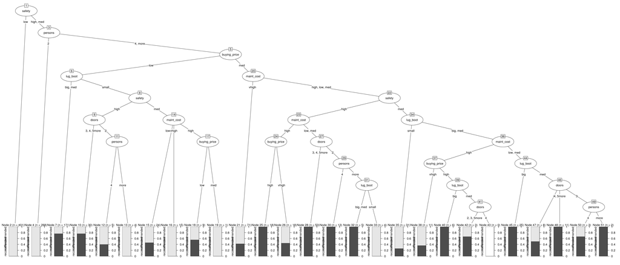

```r
plot(c5_tree)
```

## Evaluating the model

### Predictions on the test data

- We’ll evaluate the decision tree using the standard error metrics on test data

```r
preds <- predict(c5_tree, test_data)
```

- Error metrics for classification can be accessed through the “confusionMatrix()” function from the caret package

```r
library(caret)

confusionMatrix(preds, test_data$decision)
```

```
## Confusion Matrix and Statistics
##
##                 Reference
## Prediction       notRecommended recommended
##   notRecommended            359           3
##   recommended                 4         152
##
##                Accuracy : 0.9865
##                  95% CI : (0.9724, 0.9946)
##     No Information Rate : 0.7008
##     P-Value [Acc > NIR] : <2e-16
##
##                   Kappa : 0.9678
##  Mcnemar's Test P-Value : 1
##
##             Sensitivity : 0.9890
##             Specificity : 0.9806
##          Pos Pred Value : 0.9917
##          Neg Pred Value : 0.9744
##              Prevalence : 0.7008
##          Detection Rate : 0.6931
##    Detection Prevalence : 0.6988
##       Balanced Accuracy : 0.9848
##
##        'Positive' Class : notRecommended
##
```

# CART Trees

- The classification and regression trees use gini index in place of the gain ratio (based on information gain) used by the ID3 based algorithms, such as c4.5 and c5.0

## Implementing CART on the previous dataset

```r
#Tree based model
library(rpart)
rpart_tree <- rpart(decision ~ . , data = train_data, method="class")
 # default cp = 0.01
```

## Tree Explicability

- The variable importance can be accesssed using variable.importance from the rpart_tree list

```r
rpart_tree$variable.importance
```

```
##      persons       safety   maint_cost buying_price     lug_boot
##   163.392070   129.467196    70.366813    62.592487    19.625913
##        doors
##     5.925809
```

## Evaluating the model

### Predictions on the test data

- We’ll evaluate the decision tree using the standard error metrics on test data

```r
preds_rpart <- predict(rpart_tree, test_data, type="class")
```

- Error metrics for classification can be accessed through the “confusionMatrix()” function from the caret package

```r
library(caret)

confusionMatrix(preds_rpart, test_data$decision)
```

```
## Confusion Matrix and Statistics
##
##                 Reference
## Prediction       notRecommended recommended
##   notRecommended            350           2
##   recommended                13         153
##
##                Accuracy : 0.971
##                  95% CI : (0.9527, 0.9837)
##     No Information Rate : 0.7008
##     P-Value [Acc > NIR] : < 2.2e-16
##
##                   Kappa : 0.9323
##  Mcnemar's Test P-Value : 0.009823
##
##             Sensitivity : 0.9642
##             Specificity : 0.9871
##          Pos Pred Value : 0.9943
##          Neg Pred Value : 0.9217
##              Prevalence : 0.7008
##          Detection Rate : 0.6757
##    Detection Prevalence : 0.6795
##       Balanced Accuracy : 0.9756
##
##        'Positive' Class : notRecommended
##
```

## Goal -CART for regression

- The goal of this activity is to predict the imbd score of a movie using a classification and regression tree (cart)

## Agenda

- Get the data
- Data Pre-processing
- Build a model
- Predictions
- Communication

## Reading & Understanding the Data

### Read the Data

- Make sure the dataset is located in your current working directory, or else you can change your working directory using the “setwd()” function.
- While reading in the data using the read.csv() function, make sure that you mention the argument (na.strings = “”) as the data has empty values (“”) which will not be encoded as NA values when the csv file is read into the R environment

```r
mov_data <- read.csv("movie_data.csv", na.strings = "")
```

- Select only a subset of columns from the original data for this exercise

```r
movie_data <- mov_data[, names(mov_data) %in%
                         c("color", "num_critic_for_reviews", "duration", "director_facebook_likes",
                           "gross", "cast_total_facebook_likes", "num_user_for_reviews", "budget",
                           "movie_facebook_likes", "imdb_score")]
```

### Understand the data

- Use the str(), summary(), head() and tail() functions to get the dimensions and types of attributes in the dataset
- The dataset has 5043 observations and 10 variables after extracting only the important columns

```r
str(movie_data)
```

```
## 'data.frame':    5043 obs. of  10 variables:
##  $ color                    : Factor w/ 2 levels " Black and White",..: 2 2 2 2 NA 2 2 2 2 2 ...
##  $ num_critic_for_reviews   : int  723 302 602 813 NA 462 392 324 635 375 ...
##  $ duration                 : int  178 169 148 164 NA 132 156 100 141 153 ...
##  $ director_facebook_likes  : int  0 563 0 22000 131 475 0 15 0 282 ...
##  $ gross                    : int  760505847 309404152 200074175 448130642 NA 73058679 336530303 200807262 458991599 301956980 ...
##  $ cast_total_facebook_likes: int  4834 48350 11700 106759 143 1873 46055 2036 92000 58753 ...
##  $ num_user_for_reviews     : int  3054 1238 994 2701 NA 738 1902 387 1117 973 ...
##  $ budget                   : num  2.37e+08 3.00e+08 2.45e+08 2.50e+08 NA ...
##  $ imdb_score               : num  7.9 7.1 6.8 8.5 7.1 6.6 6.2 7.8 7.5 7.5 ...
##  $ movie_facebook_likes     : int  33000 0 85000 164000 0 24000 0 29000 118000 10000 ...
```

```r
summary(movie_data)
```

```
##               color      num_critic_for_reviews    duration
##   Black and White: 209   Min.   :  1.0          Min.   :  7.0
##  Color           :4815   1st Qu.: 50.0          1st Qu.: 93.0
##  NA's            :  19   Median :110.0          Median :103.0
##                          Mean   :140.2          Mean   :107.2
##                          3rd Qu.:195.0          3rd Qu.:118.0
##                          Max.   :813.0          Max.   :511.0
##                          NA's   :50             NA's   :15
##  director_facebook_likes     gross           cast_total_facebook_likes
##  Min.   :    0.0         Min.   :      162   Min.   :     0
##  1st Qu.:    7.0         1st Qu.:  5340988   1st Qu.:  1411
##  Median :   49.0         Median : 25517500   Median :  3090
##  Mean   :  686.5         Mean   : 48468408   Mean   :  9699
##  3rd Qu.:  194.5         3rd Qu.: 62309438   3rd Qu.: 13756
##  Max.   :23000.0         Max.   :760505847   Max.   :656730
##  NA's   :104             NA's   :884
##  num_user_for_reviews     budget            imdb_score
##  Min.   :   1.0       Min.   :2.180e+02   Min.   :1.600
##  1st Qu.:  65.0       1st Qu.:6.000e+06   1st Qu.:5.800
##  Median : 156.0       Median :2.000e+07   Median :6.600
##  Mean   : 272.8       Mean   :3.975e+07   Mean   :6.442
##  3rd Qu.: 326.0       3rd Qu.:4.500e+07   3rd Qu.:7.200
##  Max.   :5060.0       Max.   :1.222e+10   Max.   :9.500
##  NA's   :21           NA's   :492
##  movie_facebook_likes
##  Min.   :     0
##  1st Qu.:     0
##  Median :   166
##  Mean   :  7526
##  3rd Qu.:  3000
##  Max.   :349000
##
```

```r
head(movie_data)
```

```
##   color num_critic_for_reviews duration director_facebook_likes     gross
## 1 Color                    723      178                       0 760505847
## 2 Color                    302      169                     563 309404152
## 3 Color                    602      148                       0 200074175
## 4 Color                    813      164                   22000 448130642
## 5  <NA>                     NA       NA                     131        NA
## 6 Color                    462      132                     475  73058679
##   cast_total_facebook_likes num_user_for_reviews    budget imdb_score
## 1                      4834                 3054 237000000        7.9
## 2                     48350                 1238 300000000        7.1
## 3                     11700                  994 245000000        6.8
## 4                    106759                 2701 250000000        8.5
## 5                       143                   NA        NA        7.1
## 6                      1873                  738 263700000        6.6
##   movie_facebook_likes
## 1                33000
## 2                    0
## 3                85000
## 4               164000
## 5                    0
## 6                24000
```

```r
tail(movie_data)
```

```
##      color num_critic_for_reviews duration director_facebook_likes gross
## 5038 Color                     14       95                       0  4584
## 5039 Color                      1       87                       2    NA
## 5040 Color                     43       43                      NA    NA
## 5041 Color                     13       76                       0    NA
## 5042 Color                     14      100                       0 10443
## 5043 Color                     43       90                      16 85222
##      cast_total_facebook_likes num_user_for_reviews budget imdb_score
## 5038                       690                   14   9000        6.4
## 5039                      2283                    6     NA        7.7
## 5040                      1753                  359     NA        7.5
## 5041                         0                    3   1400        6.3
## 5042                      2386                    9     NA        6.3
## 5043                       163                   84   1100        6.6
##      movie_facebook_likes
## 5038                  413
## 5039                   84
## 5040                32000
## 5041                   16
## 5042                  660
## 5043                  456
```

## Data Pre-processing

### Verify Data Integrity

- Verify if the dataset has missing values

```r
sum(is.na(movie_data))
```

```
## [1] 1585
```

- We shall impute the missing values after splitting the data into train/test
- Verify the data types assigned to the variables in the dataset

```r
str(movie_data)
```

```
## 'data.frame':    5043 obs. of  10 variables:
##  $ color                    : Factor w/ 2 levels " Black and White",..: 2 2 2 2 NA 2 2 2 2 2 ...
##  $ num_critic_for_reviews   : int  723 302 602 813 NA 462 392 324 635 375 ...
##  $ duration                 : int  178 169 148 164 NA 132 156 100 141 153 ...
##  $ director_facebook_likes  : int  0 563 0 22000 131 475 0 15 0 282 ...
##  $ gross                    : int  760505847 309404152 200074175 448130642 NA 73058679 336530303 200807262 458991599 301956980 ...
##  $ cast_total_facebook_likes: int  4834 48350 11700 106759 143 1873 46055 2036 92000 58753 ...
##  $ num_user_for_reviews     : int  3054 1238 994 2701 NA 738 1902 387 1117 973 ...
##  $ budget                   : num  2.37e+08 3.00e+08 2.45e+08 2.50e+08 NA ...
##  $ imdb_score               : num  7.9 7.1 6.8 8.5 7.1 6.6 6.2 7.8 7.5 7.5 ...
##  $ movie_facebook_likes     : int  33000 0 85000 164000 0 24000 0 29000 118000 10000 ...
```

- The data types of the variables were properly assigned

### Split the Data into train and test sets

- As this is a regression problem, we use only random sampling for the train/test split (70/30)

```r
set.seed(1234)

train_rows <- sample(1:nrow(movie_data), 0.7*nrow(movie_data))

train_reg <- movie_data[train_rows, ]

test_reg <- movie_data[-train_rows, ]
```

### Impute the missing values

- Let’s first impute the missing values in the training data

```r
library(DMwR)
# train_reg <- knnImputation(train_reg, k = 5, scale = T)
imputer <- preProcess(train_reg,method = "knnImpute")
train_reg = predict(imputer,train_reg)
test_reg = predict(imputer,test_reg)
```

## Build a Regression Tree

### Model the tree

- We will be using the cart based decision tree algorithm implementation from the rpart package to build our regression tree

```r
library(rpart)

reg_tree <- rpart(imdb_score ~ ., train_reg)
```

### Tree Explicability

- The variable importance can accessed accessing variable.importance from the reg.tree list

```r
reg_tree$variable.importance
```

```
##                  duration      movie_facebook_likes
##                 434.08051                 349.92599
##                     gross    num_critic_for_reviews
##                 151.90906                 118.84953
##      num_user_for_reviews                    budget
##                 115.92614                  67.67027
##   director_facebook_likes cast_total_facebook_likes
##                  38.23187                  27.13012
```

- We can plot the regression tree using the rpart.plot() function from the rpart.plot package

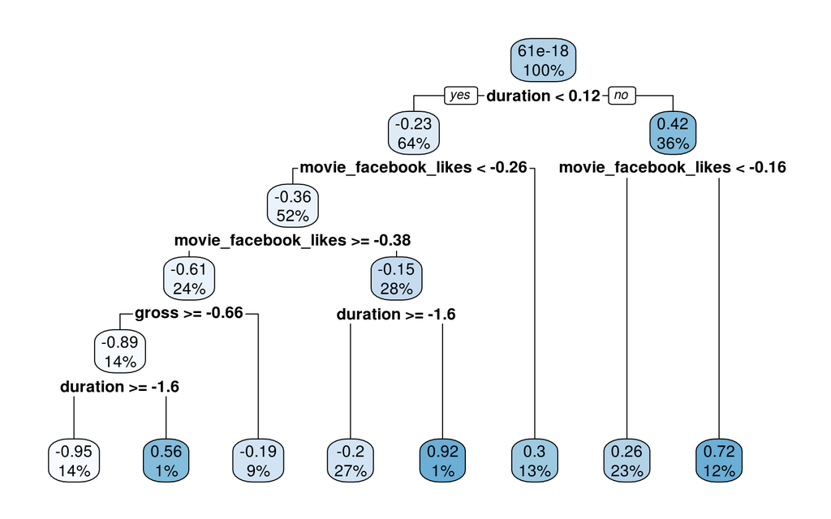

```r
library(rpart.plot)

rpart.plot(reg_tree)
```

```r
reg_preds = predict(reg_tree,test_reg)
regr.eval(trues =test_reg$imdb_score,reg_preds)
```

```
##       mae       mse      rmse      mape
## 0.7100303 0.8610223 0.9279129 1.4994964
```

## Find the best cp using print cp function

```r
printcp(reg_tree)
```

```
##
## Regression tree:
## rpart(formula = imdb_score ~ ., data = train_reg)
##
## Variables actually used in tree construction:
## [1] duration             gross                movie_facebook_likes
##
## Root node error: 3529/3530 = 0.99972
##
## n= 3530
##
##         CP nsplit rel error  xerror     xstd
## 1 0.097873      0   1.00000 1.00043 0.029091
## 2 0.044925      1   0.90213 0.90301 0.026990
## 3 0.027372      2   0.85720 0.85982 0.025793
## 4 0.016888      4   0.80246 0.81668 0.025972
## 5 0.013326      5   0.78557 0.80716 0.026264
## 6 0.011805      6   0.77224 0.80104 0.026278
## 7 0.010000      7   0.76044 0.79107 0.026520
```

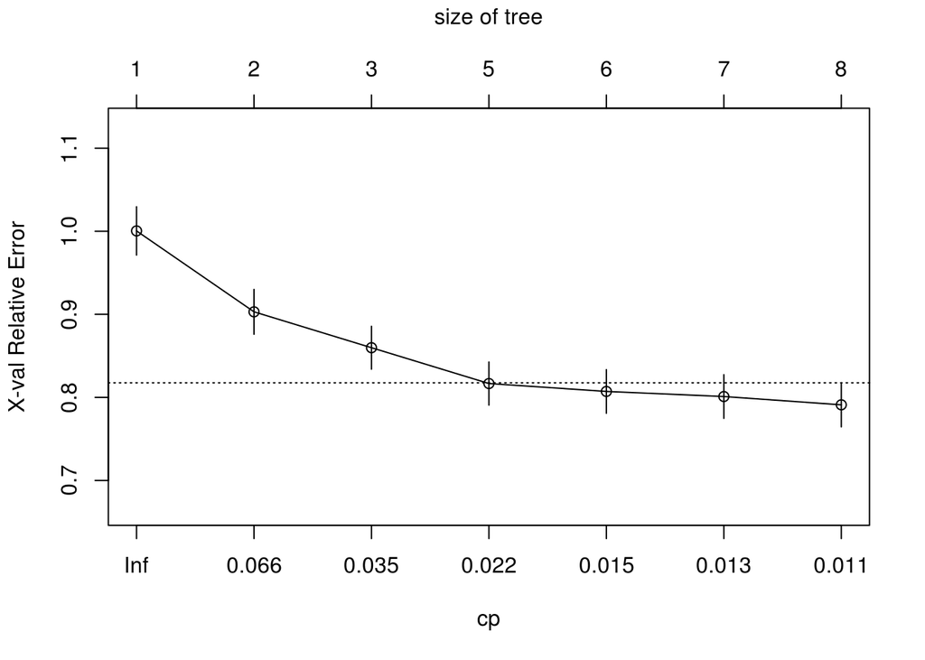

```r
plotcp(reg_tree)
```

- Based on the output, what is the optimal cp value?

```r
reg_tree1 <- rpart(imdb_score ~ ., train_reg, control = rpart.control(cp =0.016888))

reg_preds1 = predict(reg_tree1,test_reg)

regr.eval(trues = test_reg$imdb_score,reg_preds1)
```

```
##       mae       mse      rmse      mape
## 0.7243398 0.8979436 0.9475988 1.4647648
```